# Assignment 6

## Try to submit as an HTML file

Print your Emory code below

```python
print(2671215)
```

```
2671215
```

Import the "pandas" and "matplotlib.pyplot" libraries

```python
import pandas as pd
import matplotlib.pyplot as plt
```

(a) Functions

- Read the dataset labelled features.csv.
- Create a `lambda` function that checks if displacement $>$ 200
- Create a new list that shows true if displacement $>$ 200 and false

if displacement $\leq$ 200.

- Count how many cars have displacement $> 200$.

To get full credit use either the apply or the map function  
(see Lectures 7 and 8)

```python
features = pd.read_csv('data/features.csv')

myfunction = lambda displacement: displacement > 200
features['high_displacement'] = features['displacement'].apply(myfunction)
high_displacement = features[features['high_displacement'] == True]
print(high_displacement.shape[0])
```

```
158
```

(b) Subsetting Data

- Read the dataset labelled features.csv.
- Define a global variable called `threshold` that takes the

value 2588

- Subset the data to get one dataset with weight $>$ threshold and

another with weight $\le$ 2588. Use the `.query()` function.

- Compute the mean acceleration for each of these datasets.

Note: Review how to define a gloabl variable inside `.query()`

```python
threshold = 2588
large_weight = features.query('weight > @threshold')
low_weight = features.query('weight <= @threshold')
print(large_weight['acceleration'].mean())
print(low_weight['acceleration'].mean())
```

```
14.972457627118644
16.435802469135798
```

(c) Use sorting + ".iloc[]"

- Read the "fifa23_players_basic.csv" dataset
- Use ".sort_values()" to order the "Age" column

from youngest to oldest

- Get a subset with the 5 youngest players

```python
fifa=pd.read_csv('data/fifa23_players_basic.csv')
fifa_age=fifa.sort_values(by='Age', ascending=True)
youngest_players=fifa_age.head(5)
```

(d) Use queries + global variables

- Read the "fifa23_players_basic.csv" dataset
- Compute the mean of the column "Wage(in Euro)"

and store it as a variable

- Subset the players whose value is above the mean value  
  using ".query()"

HINT: Remember that there is a special syntax for  
when the column names have spaces (see Lecture 10)  
Reference the column as `` `Wage(in Euro)` `` inside .query()

```python
mean_wage=fifa['Wage(in Euro)'].mean()
high_wage=fifa.query('`Wage(in Euro)` > @mean_wage')
```

(e) Plot by Category

Read the "data/wdi_urban.csv" dataset.

This contains data from 1980 and 2020.

- **Create a list with the unique values of "year"**
- **Create a plot with a ...**
  - Histogram of "prop_urbanpopulation" for each year
  - Set the histogram option `alpha = 0.5` for transparency
  - All the histograms should be overlapping
  - Create a legend with the list of years
  - Label the axes and the title

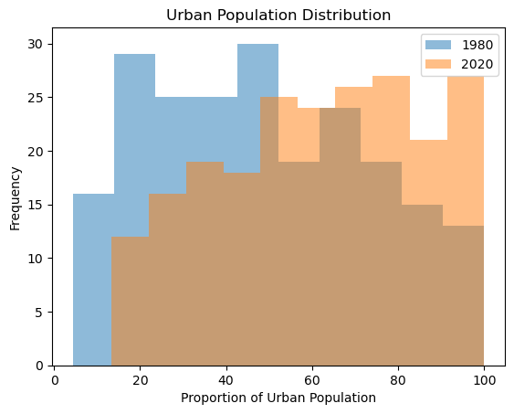

```python
wdi=pd.read_csv('data/wdi_urban.csv')
year_list=wdi['year'].unique()
year1=wdi[wdi['year']==year_list[0]]
year2=wdi[wdi['year']==year_list[1]]
plt.hist(year1['prop_urbanpopulation'],alpha=0.5)
plt.hist(year2['prop_urbanpopulation'],alpha=0.5)
plt.legend(year_list)
plt.xlabel('Proportion of Urban Population')
plt.ylabel('Frequency')
plt.title('Urban Population Distribution')
plt.show()
```